[figure not shown]

Visual Story Telling

From Data to Narrative: Crafting Stories through Visualization!

Visual storytelling is a data communication technique that employs a range of visualization techniques to narrate the story behind a dataset or set of datasets in a seamless and cohesive manner. The primary goal of visual storytelling is to convey a single key message, accompanied by several sub-messages, through the effective use of visual aids. We need to be careful about the amount of information we include in a visual story, as the human brain has limited capacity for processing and comprehending complex information. As such, the success of visual storytelling lies in its ability to present complex data in a simplified, digestible manner, allowing viewers to understand and engage with the data presented.

Considering the multi-dimensional aspects of public health data, visual storytelling is a powerful technique in this field to effectively communicate complex health-related information to a wide range of audiences. Public health matters often involve intricate data and statistics, but visual storytelling simplifies them and makes them more memorable. Emotionally engaging visuals such as infographics, photos, and videos can motivate people to take action to improve their health. Furthermore, visual storytelling can help overcome health disparities by providing health information that is accessible to individuals with limited literacy or language barriers. By combining data visualization techniques with narrative storytelling, visual storytelling can help to distill vast amounts of public health data into a clear and compelling message, highlighting trends, patterns, and relationships that might otherwise go unnoticed.

Visual storytelling can be used in various public health contexts, including health promotion, disease prevention, epidemiology, and health education. For example, visual stories can be used to explain the prevalence and spread of a particular disease, the impact of certain health policies, or the success of a public health intervention. The following story presents data on the [Mental Health Characteristics and Suicidal Thoughts](https://open.canada.ca/data/en/dataset/c5cad8c6-f8bd-44ef-a454-86acfe30c1c3) in Canada by sex and province, as provided by the Government of Canada’s open data platform.

### Story #2: Suicidal thoughts among Canadians!

[figure not shown]

To generate this visualization, we use the following visualization techniques:

#### Comet Chart

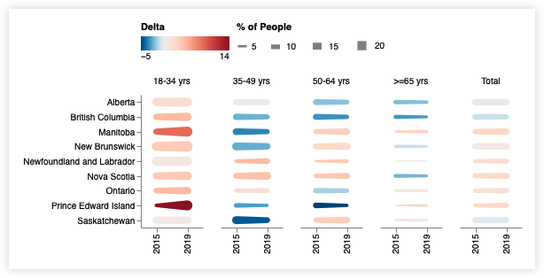

#### Bar Chart

To show the prevalence of suicidal thoughts and the rates of seeking professional help across different age categories in both 2015 and 2019, we have utilized a bar chart. Please refer to the included image for specific details on the variables used in this visualization, as well as any relevant filters and configurations.

[figure not shown]

The background image for this dashboard was obtained from [Free Pick](https://www.freepik.com/) and it can be downloaded from [here](https://github.com/HIVE-UofT/Health-Data-Visualization/blob/main/Lecture07/Story%20Images/Suicidal%20Thoughts.zip?raw=true) for reference.